# Attendance and Volatility in Aotearoa

Tamara Butigan

2025-06-22

### Executive summary

This report delivers a brief, data-driven analysis of school attendance patterns and volatility across Aotearoa’s education regions, with a strong focus on equity and risk. The analysis uses cleaned administrative datasets and robust statistical methods to uncover trends and actionable insights for policymakers. The main findings are:

**Volatility matters**: Beyond average attendance rates, volatility (instability in attendance) emerges as a key risk factor for student disengagement. Volatility accounts for about 37% of the variation explained by the combined risk model, with EQI accounting for around 63%. This underscores that while socioeconomic factors are the dominant influence, volatility (attendance instability) is a substantial additional predictor of disengagement risk.

**Long-term challenges persist**: While recent years show modest recovery in attendance, most regions have not returned to pre-pandemic levels, and long-term trends remain largely negative.

**Targeted risk typologies**: By combining Equity Index (EQI) scores and volatility, regions are classified into risk typologies—enabling more precise, evidence-based targeting of interventions.

**Regional deep-dive**: Focused analysis of the Taranaki, Whanganui, Manawatu region reveals growing post-pandemic instability, underscoring the need for nuanced, localised responses. The usefulness of volatility as a regional metric is reduced for a region as diverse as Taranaki, as data aggregation can mask important trends.

**Next steps**:

> Analyzing volatility at the school level increases statistical power to detect meaningful variation, attributes local shocks accurately, and enables precise, equity-focused intervention. Aggregated regional volatility, while informative, can mask critical differences and emerging risks at the local level. More granular volatility would also allow for predictive modelling, since we could account for other relevant school-level variables, interventions and exogenous shocks.

# Exploratory Data Analysis (EDA)

## Key Variables

We examine four core variables at the regional level: - `avg_present`: Average attendance across available years - `volatility_present`: Instability in attendance rates, calculated using the coefficient of variation (CV): volatility_present = standard deviation of yearly attendance ÷ mean yearly attendance - `eqi_mean`: Average EQI score by region - `coef_variation`: Within-region variation in attendance

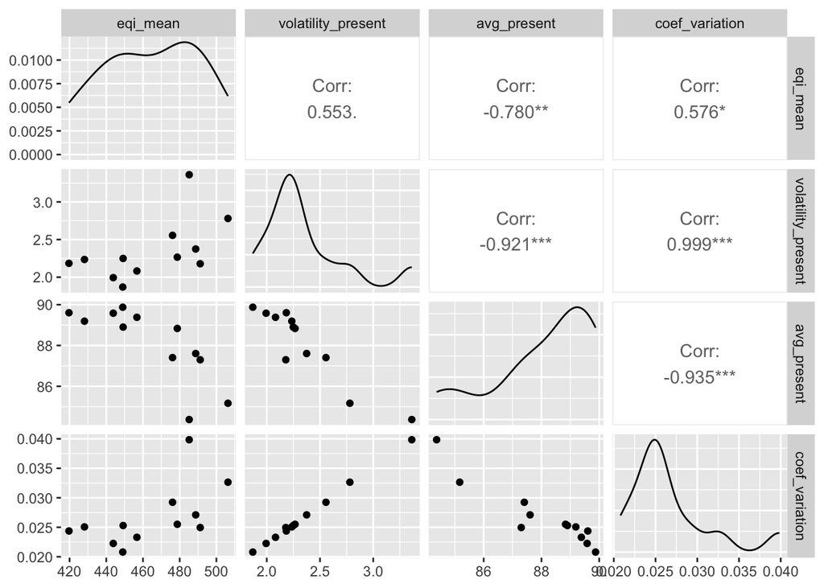

## Volatility adds predictive power beyond socioeconomic status

We examined how well average attendance (`avg_present`) can be predicted by school socioeconomic status (`eqi_mean`) and attendance volatility (`volatility_present`), including their interaction.

```
## # A tibble: 3 × 2
##   Model             R_squared
##   <chr>                 <dbl>
## 1 EQI only              0.608
## 2 EQI + Volatility      0.953
## 3 EQI + Interaction     0.961
```

> This demonstrates that attendance volatility is a key additional risk factor for disengagement beyond socioeconomic disadvantage. Policy and interventions should consider not only average attendance levels but also the stability of attendance patterns.

# Regional Attendance Trends

We model term attendance percentage over time per education region, using different time windows for comparison:

1. Long-Term Trend (2011–2024, excluding COVID)
2. Recent trend only (2022–2024)

## Side-by-Side Comparison of Trends

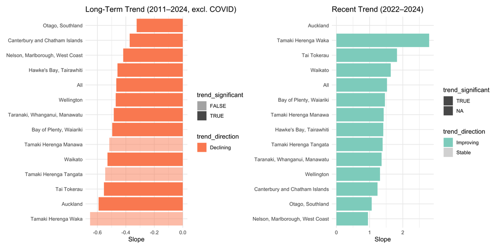

While the 2022–2024 trend appears to show improving attendance in many regions, this likely reflects a recovery from the sharp pandemic-era declines. The long-term trend (2011–2024, excluding COVID years) is still negative or stable for most regions, indicating that attendance has not returned to pre-COVID levels.This suggests that the recent improvements may be real—but modest—and not yet sufficient to reverse a longer trajectory of disengagement. We explore this assumption in the chart below, comparing 2018 and 2024 attendance levels.

## 2018 vs 2024 Attendance Comparison

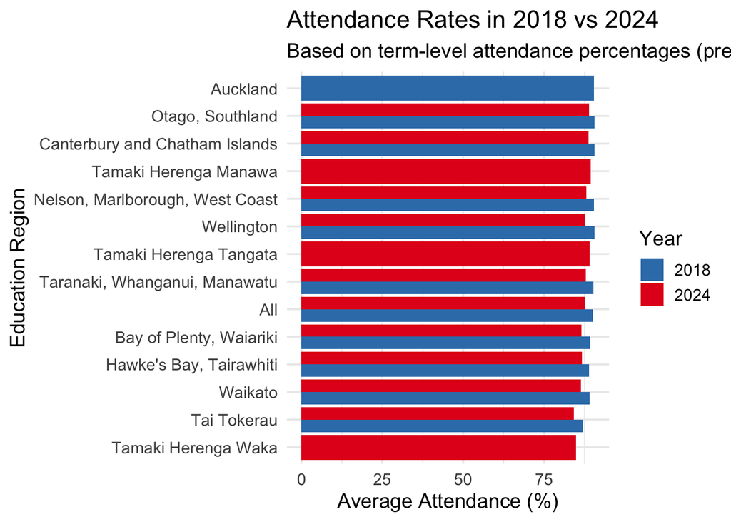

None of the regions have returned to their 2018 attendance levels yet.

# Volatility and COVID Impact (Taranaki, Whanganui, Manawatu)

In this section, we focus on the region “Taranaki, Whanganui, Manawatu”.

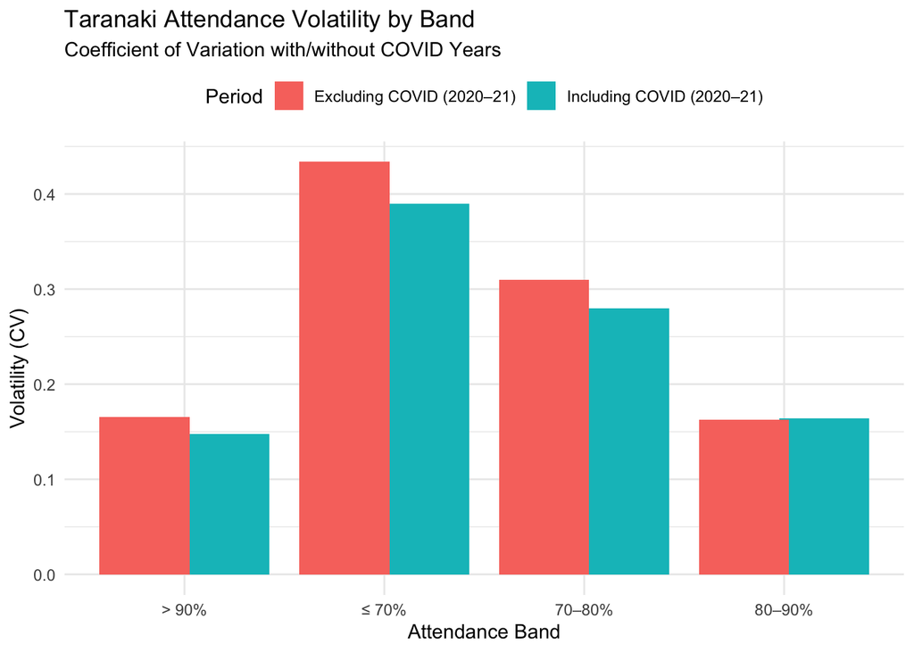

# Yearly Volatility Trends in Taranaki Region

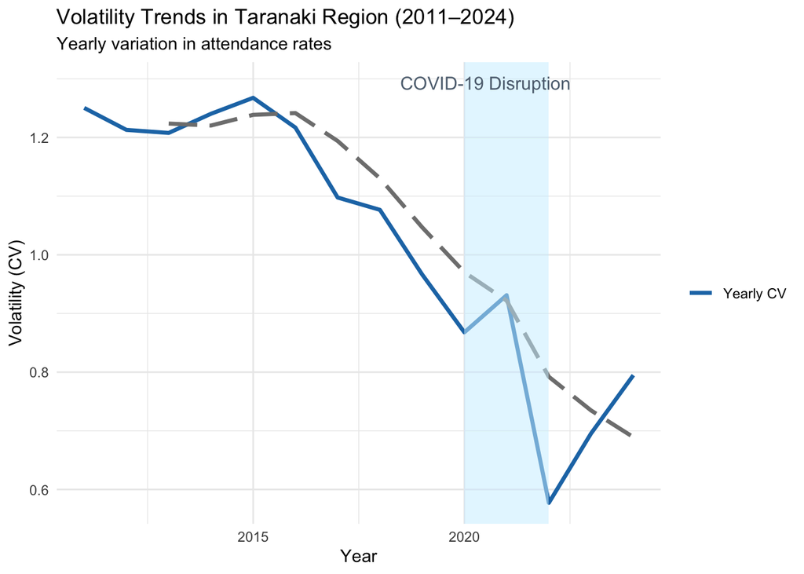

## Taranaki attendance volatility shows three distinct phases:

- 2016-2019: Steady improvement in stability (volatility dropped from 1.25 to 1.0)
- 2020-2022: COVID created the most stable period ever (volatility fell to 0.58) as lockdowns affected all schools uniformly
- 2023-2024: Recovery brought new instability (volatility rose to 0.78) as schools recovered at different rates, creating a “new normal” that’s more volatile than the COVID period but more stable than pre-2016

## What this means for Taranaki:

# Risk Typology Based on EQI and Volatility

We construct a regional risk score combining EQI and volatility and assign typologies:

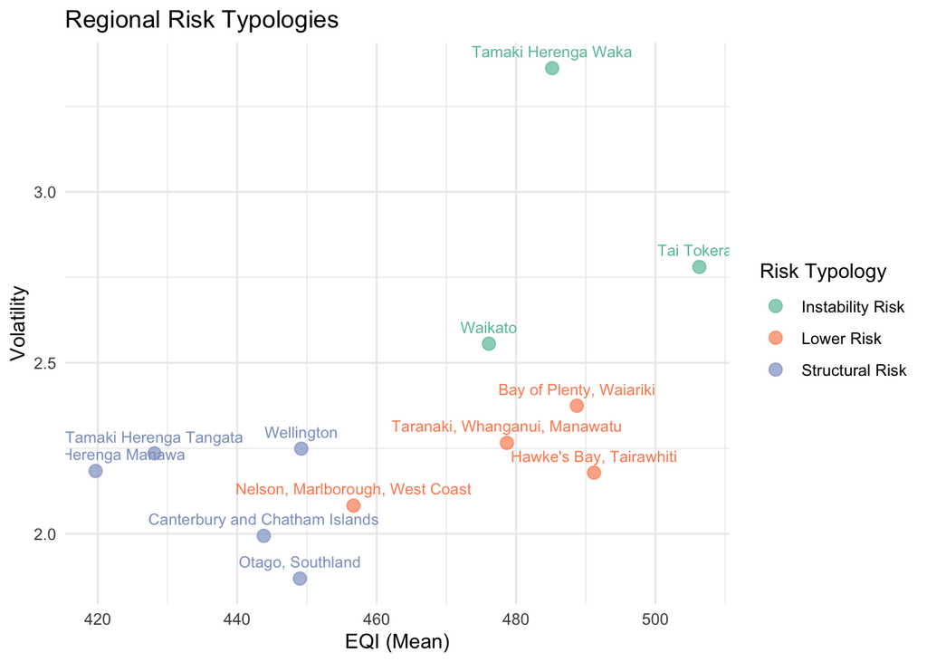

### Key Takeaway

Regions can be differentiated into typologies based on **structural disadvantage and attendance volatility**, helping to target interventions.

# Summary

Key Points:

- No NZ region has returned to pre-COVID attendance levels
- Post-pandemic recovery created new instability
- Regions can be classified by combining socioeconomic disadvantage with volatility for targeted interventions
- School-level data needed—regional analysis masks local differences

> Bottom line: Policymakers can focus on attendance volatility alongside overall rates, using different approaches for EQI-driven versus unpredictable attendance patterns. Volatility becomes a more useful metric with granular, school-level data rather than aggregated regional data.